# Report Template for Jellybeans and Dietary Lifestyle as Predictors of Height

Author

Joseph Dainis and Austin Hill

The structure below is one possible setup for a report stemming from a data analysis project. It loosely follows the structure of a standard scientific manuscript. Adjust as needed. You don’t need to have exactly these sections, but the content covering those sections should be addressed.

This uses [HTML as output format](https://quarto.org/docs/output-formats/html-basics.html). See [the Quarto documentation](https://quarto.org/) for instructions on how to use other formats.

# 1 Introduction

## 1.1 Description of data and data source

*Describe what the data is, what it contains, where it is from, etc. Eventually this might be part of a methods section.*

Two variables were added to the dataset. The first variable looks at the number of jellybeans found in the pockets of the individuals, as individuals were given full access to the largest bowl of jellybeans known to man before they were sampled for data. The second variable looks at the dietary lifestyle of those interviewed in this dataset, differentiating the group between vegans, vegetarians, omnivores and meateaters.

# 2 Methods

*Describe your methods. That should describe the data, the cleaning processes, and the analysis approaches. You might want to provide a shorter description here and all the details in the supplement.*

# 3 Results

## 3.1 Exploratory/Descriptive analysis

*Use a combination of text/tables/figures to explore and describe your data. Show the most important descriptive results here. Additional ones should go in the supplement. Even more can be in the R and Quarto files that are part of your project.*

Table 1 shows a summary of the data.

Note the loading of the data providing a **relative** path using the `../../` notation. (Two dots means a folder up). You never want to specify an **absolute** path like `C:\yourname\yourproject\results\` because if you share this with someone, it won’t work for them since they don’t have that path. You can also use the `here` R package to create paths. See examples of that below. I generally recommend the `here` package.

| skim_type | skim_variable | n_missing | complete_rate | factor.ordered | factor.n_unique | factor.top_counts | numeric.mean | numeric.sd | numeric.p0 | numeric.p25 | numeric.p50 | numeric.p75 | numeric.p100 | numeric.hist |
| --- | --- | --- | --- | --- | --- | --- | --- | --- | --- | --- | --- | --- | --- | --- |
| factor | Gender | 0 | 1 | FALSE | 3 | F: 3, M: 3, O: 2 | NA | NA | NA | NA | NA | NA | NA | NA |
| factor | Food_lifestyle | 0 | 1 | FALSE | 4 | Omn: 3, Mea: 2, Veg: 2, Veg: 1 | NA | NA | NA | NA | NA | NA | NA | NA |
| numeric | Height | 0 | 1 | NA | NA | NA | 165.625 | 17.07912 | 133 | 155.50 | 170.5 | 178.50 | 183 | ▂▁▃▂▇ |
| numeric | Weight | 0 | 1 | NA | NA | NA | 72.000 | 21.88933 | 45 | 53.75 | 73.0 | 82.50 | 110 | ▇▂▅▂▂ |
| numeric | Jellybeans_in_pocket | 0 | 1 | NA | NA | NA | 2771.500 | 3926.01976 | 2 | 7.25 | 162.5 | 5541.75 | 9383 | ▇▁▂▁▃ |

## 3.2 Basic statistical analysis

*To get some further insight into your data, if reasonable you could compute simple statistics (e.g. simple models with 1 predictor) to look for associations between your outcome(s) and each individual predictor variable. Though note that unless you pre-specified the outcome and main exposure, any “p<0.05 means statistical significance” interpretation is not valid.*

```r
library(here)
```

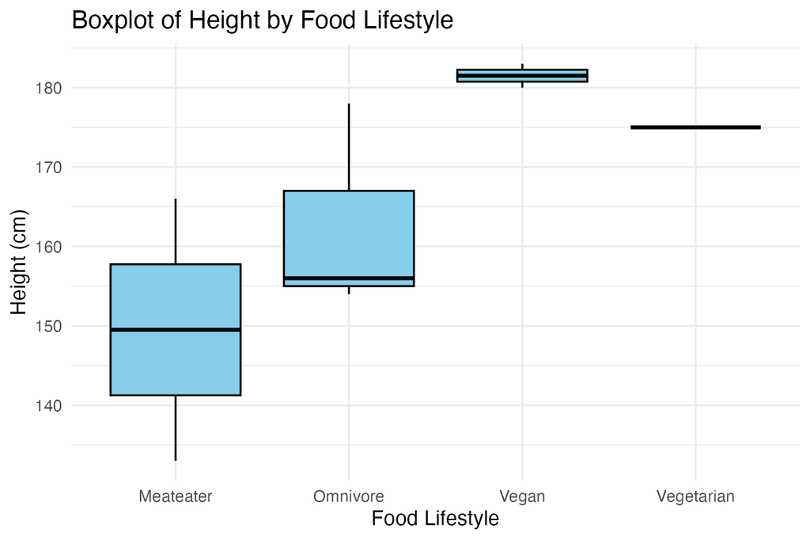

Figure 1: Height and Dietary Lifestyle Boxplot.

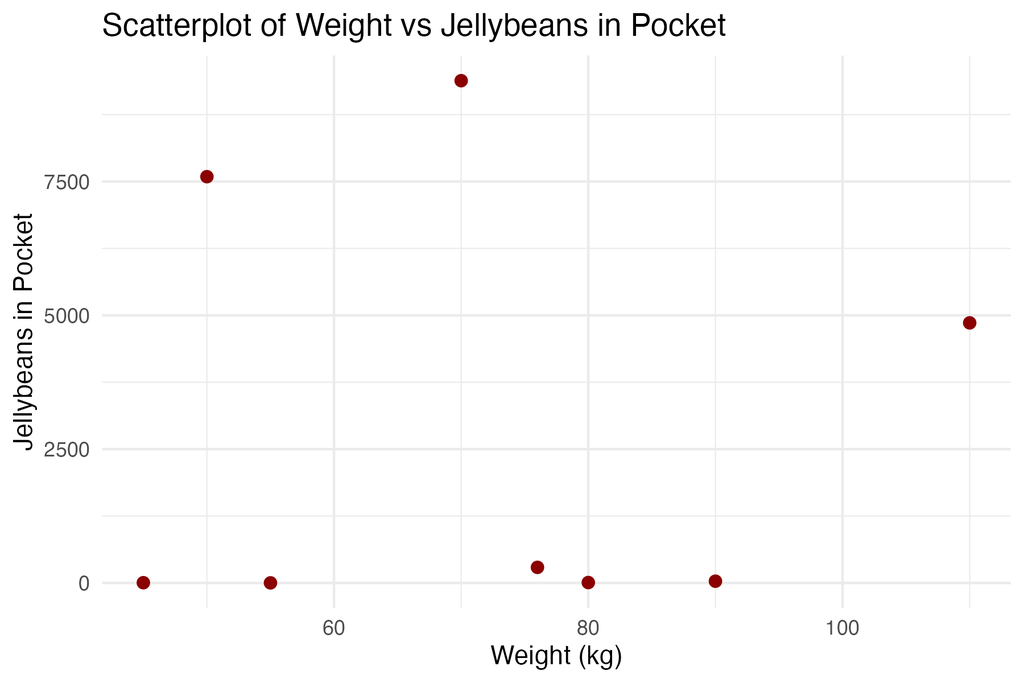

Figure 2: Weight and Jellybean Count in Pockets Scatter Plot.

## 3.3 Full analysis

*Use one or several suitable statistical/machine learning methods to analyze your data and to produce meaningful figures, tables, etc. This might again be code that is best placed in one or several separate R scripts that need to be well documented. You want the code to produce figures and data ready for display as tables, and save those. Then you load them here.*

Table 2: Linear model fit table.

| term | estimate | std.error | statistic | p.value |
| --- | --- | --- | --- | --- |
| (Intercept) | 148.5711304 | 13.63108 | 10.8994389 | 0.0016529 |
| Jellybeans_in_pocket | 0.0003819 | 0.00248 | 0.1540080 | 0.8873804 |
| Food_lifestyleOmnivore | 13.0878604 | 15.78960 | 0.8288914 | 0.4679556 |
| Food_lifestyleVegan | 32.9269599 | 18.30537 | 1.7987594 | 0.1698909 |
| Food_lifestyleVegetarian | 22.8451594 | 27.30291 | 0.8367298 | 0.4641544 |

These results show that neither dietary lifestyle nor the number of jellybeans in one’s pocket are statistically significant predictors of height!